# COTS_Model

Samuel Matthews

21 November 2018

# Major Challenges

```
1. I think we need to move everything to a reef level instead of a pixel based scenario.. Having multiple COTS populations on a ref make its hard to intigate a reef wide collapse.
2. following a collapse COTS numbers stay at 0 until returning to directly to carrying capacity
3. need to build a matlines plot to show each different replicate
```

# Preparing the Workspace

This section of the model sets up the directories to access data and to save files

```r
# CLEAR THE WORKSPACE ----
#######################!

rm(list=ls())

####
# SET USER ----
####

USER = "SAM_UNI"
# USER = "SAM_RENO"


#################!
# SET GLOBAL VARIABLES  (USER SPECIFIED PARAMS) ----
####

# NREPS <- 10
NYEARS <- 20
NSEASONS <- 2
seasons <- c("summer","winter")
npops = 6000 #number of reefs we want to test

VERBOSE <- TRUE        # flag whether functions should return detailed information
DEBUG <- TRUE          # flag whether to output debug files etc.

projection <- "+proj=longlat +datum=WGS84 +no_defs +ellps=WGS84 +towgs84=0,0,0"   #"+proj=lcc +lat_1=33 +lat_2=45 +lat_0=39 +lon_0=-96 +x_0=0 +y_0=0 +ellps=GRS80 +units=m +no_defs"

stagenames <- c('J_1', 'J_2', 'A')
COTSmort <- c(0.8,0.7,0.2)
names(COTSmort) <- stagenames
COTSremain <- c(0.02,0.2,1) # proportion remianing in each life stage --> we can make this a function of resource
names(COTSremain) <- stagenames
#VBG.Params = VBG.Models[[2]]

COTS_StableStage <- c(0.9803, 0.0171, 0.0026)   # very approximate stable stage distribution (J1, J2, Adult: see below for back-of-the-envelope calculation)
```

## Set Project Directories

```r
####
# SET PROJECT DIRECTORIES ----
####

# (this should be the only place where local directories should be referenced)

if(USER=="KEVIN") BASE_DIRECTORY <- "C:\\Users\\Kevin\\Dropbox\\CoTS_Model"             # NOTE: this should link to the Dropbox folder with shared project resources
if(USER=="KEVIN") CODE_DIRECTORY <- "C:\\Users\\Kevin\\GIT\\COTS_Model"              # NOTE: code directory should be your local copy of the GitHub repository

if(USER=="SAM") BASE_DIRECTORY <- "C:\\Users\\jc312264\\Dropbox\\CoTS_Model"
if(USER=="SAM") CODE_DIRECTORY <- "C:\\Users\\jc312264\\Documents\\GitHub\\COTS_Model"

if(USER=="SAM_UNI") BASE_DIRECTORY <- "C:\\Users\\jc312264\\Dropbox\\CoTS_Model"
if(USER=="SAM_UNI") CODE_DIRECTORY <- "C:\\Users\\jc312264\\OneDrive - James Cook University\\GitHub\\COTS_Model"

if(USER=="SAM_RENO") BASE_DIRECTORY <- "C:\\Users\\kshoemaker\\Dropbox\\CoTS_Model"
if(USER=="SAM_RENO") CODE_DIRECTORY <- "C:\\Users\\kshoemaker\\Documents\\GitHub\\COTS_Model"

SPATIALDATA_DIRECTORY <- paste(BASE_DIRECTORY,"\\Spatial Layers",sep="")                          # directory for storing relevant spatial data (ASC, SHP files)
if(is.na(file.info(SPATIALDATA_DIRECTORY)[1,"isdir"])) dir.create(SPATIALDATA_DIRECTORY)

DATA_DIRECTORY <- paste(BASE_DIRECTORY,"\\Data",sep="")                                 # directory for storing data (CSV files)
if(is.na(file.info(DATA_DIRECTORY)[1,"isdir"])) dir.create(DATA_DIRECTORY)

ENVDATA_DIRECTORY <- paste(DATA_DIRECTORY,"\\Environmental",sep="")                                 # directory for storing data (CSV files)
if(is.na(file.info(ENVDATA_DIRECTORY)[1,"isdir"])) dir.create(ENVDATA_DIRECTORY)

FIGURES_DIRECTORY <- paste(BASE_DIRECTORY,"\\Figures\\RawFigures",sep="")               # directory for storing raw figures generated from R
if(is.na(file.info(FIGURES_DIRECTORY)[1,"isdir"])) dir.create(FIGURES_DIRECTORY)

RESULTS_DIRECTORY <- paste(BASE_DIRECTORY,"\\results",sep="")                           # directory for storing relevant results
if(is.na(file.info(RESULTS_DIRECTORY)[1,"isdir"])) dir.create(RESULTS_DIRECTORY)

RDATA_DIRECTORY <- paste(BASE_DIRECTORY,"\\R_Workspaces",sep="")                        # directory for storing .RData files (R workspaces and data objects)
if(is.na(file.info(RDATA_DIRECTORY)[1,"isdir"])) dir.create(RDATA_DIRECTORY)

cat(sprintf("The current user is %s",USER))
```

```
## The current user is SAM_UNI
```

## Load Functions, Packages and Data

```r
##################!
# LOAD FUNCTIONS AND SCRIPTS FROM SOURCE CODE (your local GitHub repository) ----
##################!

setwd(CODE_DIRECTORY)
source("COTSModel_Utilityfunctions.R")   # load utility functions, e.g., for loading packages etc.
source("COTSModel_COTSfunctions.R")      # load functions for implementing COTS demography and dispersal
source("COTSModel_Coralfunctions.R")     # load functions for implemeting coral growth/recovery and dispersal
source("COTSModel_GISfunctions.R")     # load functions for implemeting coral growth/recovery and dispersal

#####################!
# LOAD PACKAGES ----
#####################!
# note: 'loadPackage' should install the package from CRAN automatically if it is not already installed

loadPackages()   # load all packages into the global environment
# THis only installs packages now.. everything else will be defined inline

`%>%` <- magrittr::`%>%` # bringt the pipe operator into the global environment

#####################!
# LOAD DATA FOR MODELLING ----
#####################!
setwd(CODE_DIRECTORY)
source("COTSModel_LoadObjectsForModelling.R")
CC_Per_CC = (data.grid$PercentReef/10000)*1e6*1e4
COTS_Per_CC = CC_Per_CC/(250*365)
Crash=5

# save global params
saveWorkspace(filename="GlobalParams.RData", dir=RDATA_DIRECTORY)
```

# Model Structure and Functions

FIgure 1 below describes the general framework for the COTS model. A dataframe is set up to create latin hypercube samples, then the model is run for each sample and stored as a `.Rdata` file. Each function is described in detail below.

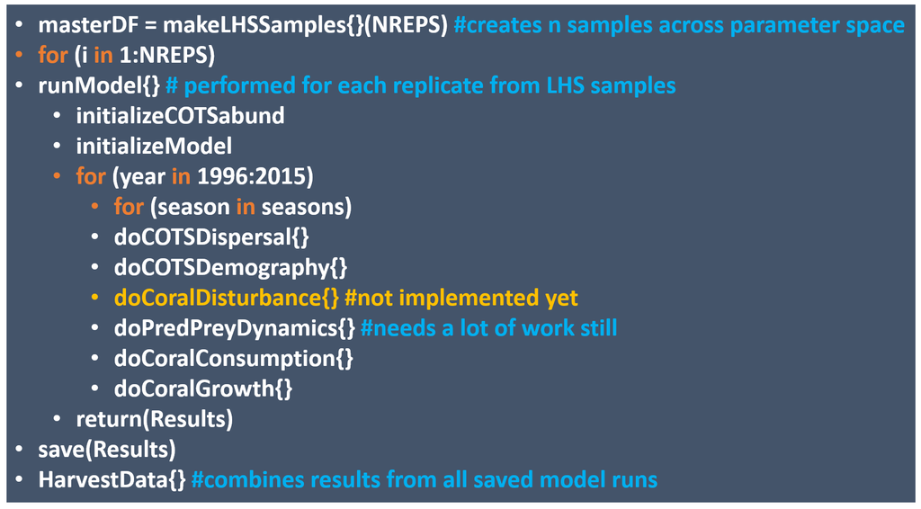

Model Structure

## makeLHSsamples

- **Objective**: This function creates *n* replicates across paremeter space for an individual model run
- **Paremeters**:
  - **NREPS**: number of replicate samples we wish to draw from parameter space
- **Returns**:
  - **masterDF**: n x 14 dataframe containing the parameters for that
  - **.csv**: masterDF is written to the Results Directory
- *Major Issues*: No major issues at this time, the biggest concern is developing more realisic densit dependent parameters to sample across

```r
MakeLHSSamples <- function(NREPS){

  # Information necessary to translate standard uniform LHS sample into parameters of interest
  specifyLHSParam <- function(paramslist,name,type,lb,ub){
    newlist <- paramslist
    eval(parse(text=sprintf("newlist$%s <- list()",name)))
    eval(parse(text=sprintf("newlist$%s$type <- \"%s\"",name,type)))
    eval(parse(text=sprintf("newlist$%s$lb <- %s",name,lb)))
    eval(parse(text=sprintf("newlist$%s$ub <- %s",name,ub)))
    return(newlist)
  }

  LHSParms <- list()    # initialize the container for parameter bounds

  ### SEXRATIO : 1 = 0.1M:0.9F
  LHSParms <- specifyLHSParam(paramslist=LHSParms,name="SexRatio",type="CAT",lb=0,ub=9)

  ####  WINTER CONSUMPTION RATE
  LHSParms <- specifyLHSParam(LHSParms,"ConsRateW",type="CONT",lb=100,ub=200)

  #### SUMMER CONSUMPTION RATE
  LHSParms <- specifyLHSParam(LHSParms,"ConsRateS",type="CONT",lb=150,ub=400)

  ### AVERAGE PER CAPITA FECUNDITY
  LHSParms <- specifyLHSParam(LHSParms,"avgPCF",type="CONT",lb=42e5,ub=21e6)

  ### STD DEV PER CAPITA FECUNDITY
  LHSParms <- specifyLHSParam(LHSParms,"sdPCF",type="CONT",lb=6e4,ub=14.6e4)

  ### % JUVENILE1 MORTALITY PER TIME STEP
  LHSParms <- specifyLHSParam(LHSParms,"mortJ1",type="CONT",lb=0.9,ub=0.99)

  ### % JUVENILE2 MORTALITY PER TIME STEP
  LHSParms <- specifyLHSParam(LHSParms,"mortJ2",type="CONT",lb=0.6,ub=0.99)

  ### % ADULT MORTALITY PER TIME STEP
  LHSParms <- specifyLHSParam(LHSParms,"mortA",type="CONT",lb=0.1,ub=0.6)

  ### % JUVENILE1 TO REMIAIN during transition
  LHSParms <- specifyLHSParam(LHSParms,"remJ1",type="CONT",lb=0.01,ub=0.5)

  ### % JUVENILE2 TO REMIAIN during transition
  LHSParms <- specifyLHSParam(LHSParms,"remJ2",type="CONT",lb=0.1,ub=0.5)

  ### % ADULT TO REMIAIN during transition
  LHSParms <- specifyLHSParam(LHSParms,"remA",type="CONT",lb=1,ub=1)

  ### PROPORTIONAL STABLE STAGE DISTRIBUTION J1
  LHSParms <- specifyLHSParam(LHSParms,"cssJ1",type="CONT",lb=0.9803,ub=0.9803)

  ### PROPORTIONAL STABLE STAGE DISTRIBUTION J2
  LHSParms <- specifyLHSParam(LHSParms,"cssJ2",type="CONT",lb=0.0171,ub=0.0171)

  ### PROPORTIONAL STABLE STAGE DISTRIBUTION a
  LHSParms <- specifyLHSParam(LHSParms,"cssA",type="CONT",lb=0.0026,ub=0.0026)


  ##### GENERATE LATIN HYPERCUBE SAMPLE

  nVars <- length(names(LHSParms))

  LHS <- lhs::randomLHS(NREPS, nVars )   # generate multiple samples from parameter space according to a LHS sampling scheme

  masterDF <- as.data.frame(LHS)    #  storage container (data frame) to record relevant details for each file. Rows LHS samples. Cols: relevant variables


  ### translate raw lhs samples into desired parameter space
  colnames(masterDF) <- names(LHSParms)
  parm=1
  for(parm in 1:nVars){
    if(LHSParms[[parm]]$type=="CONT"){
      masterDF[,parm] <- LHSParms[[parm]]$lb + LHS[,parm]*(LHSParms[[parm]]$ub-LHSParms[[parm]]$lb)
    }
    if(LHSParms[[parm]]$type=="CAT"){
      masterDF[,parm] <- ceiling(LHSParms[[parm]]$lb + LHS[,parm]*(LHSParms[[parm]]$ub-LHSParms[[parm]]$lb))
    }
  }

  setwd(RESULTS_DIRECTORY)
  ## name file for LHS parameters
  write.csv(masterDF,"masterDF_prelimCOTS.csv",row.names=F)

  return(masterDF)
}

####################!
# GENERATE LATIN HYPERCUBESAMPLE ----
####################!

masterDF = MakeLHSSamples(NREPS = 10)
```

## initalizeCOTSabund

- **Objective**: Create a npops x 3 matrix to store COTS abundances (COTSabund) as the model progress
- **Paremeters**:
  - **data.grid**: XYZ grid conatining all metadata for each pixel and environmental variables
  - **data.COTS**: interpolated COTS per manta tow dataframe used to initialize the COTS populations
  - **Year**: which year we choose to start from (usually 1996)
  - **stagenames**: character vector containing the names of the COTS stages (e.g J_1, J_2, A)
  - **COTS_StableStage**: 3 element vector conatinin the estimated proportions of J_1 and J_2 COTS to support the initialized adult population
- **Returns**:
  - **COTSabund**: npops x 3 matrix containing our starting values of COTS
- *Major Issues*: I need to make a more reliable estimate of the stable stage distribution, I can probably get this from Cameron Fletcher

```r
initializeCOTSabund <- function(data.grid, data.COTS, Year, stagenames, COTS_StableStage){
  # browser()
  ### set NA Values in interpolation CoTS.init to 0
  data.COTS[is.na(data.COTS)] <- 0

  nstages <- length(stagenames)

  ### Set up the COTS abundance object
  COTSabund <- matrix(0,nrow=npops, ncol=nstages)
  colnames(COTSabund) <- stagenames

  ### Set up reference for year
  colname <- paste('COTS_', Year, sep="")

  ### Update abundances based from interpolated manta tow data
  COTSabund[,'A'] <- round(data.COTS[,colname] * 666 * (data.grid$PercentReef/100),0)   # 666 converts manta tow to 1kmx1km
  COTSabund[,'J_2'] <- round(COTSabund[,'A'] * as.numeric(COTS_StableStage[2]/COTS_StableStage[3]),0)
  COTSabund[,'J_1'] <- round(COTSabund[,'A'] * as.numeric(COTS_StableStage[1]/COTS_StableStage[3]),0)
  return(COTSabund)
}
```

## doCOTSDispersal

```r
doCOTSDispersal = function(season, COTSabund, SexRatio, ConnMat, PCFParams, Pred, FvDParams){
  #browser()
  COTSabund = COTSabund
  if (season=="summer"){
    nEggs = COTSabund[,'A']*rnorm(1, PCFParams[1], PCFParams[2])*((10-SexRatio)/10)
    fEggs = FvDParams[SexRatio,"Linf"] * (1 - exp(-FvDParams[SexRatio,"K"] * (COTSabund[,'A'] - FvDParams[SexRatio,"t0"])))
    nLarvae = nEggs * fEggs
    # Do Dispersal ----
    nLarvae = ifelse(nLarvae < 0 , 0, nLarvae)
    nLarvae = as.matrix((1-Pred)*nLarvae) # assume 80% lost to the sea
    row.names(nLarvae) = data.grid$REEF_NAME
    nLarvae_Reef = rowsum(nLarvae, row.names(nLarvae), reorder = F)
    nArriving_Reef = ConnMat
    nArriving_Reef[nArriving_Reef > 0] = 0
    for (i in 1:length(nLarvae_Reef)) {
      nArriving_Reef[i,] = signif(nLarvae_Reef[i]*(ConnMat[i,]),3)
    }
    nArriving_Reef = base::colSums(nArriving_Reef, na.rm = T) # create total juveniles arriving at a reef
    nArriving_Reef_PerPix = nArriving_Reef/Pixels$Pixels
    names(nArriving_Reef_PerPix) = colnames(ConnMat)
    nArriving = nArriving_Reef_PerPix[match(data.grid$REEF_NAME, colnames(ConnMat))]
    COTSabund[,'J_1'] = COTSabund[,'J_1'] + nArriving # add these to our abundance
  }
  return(COTSabund)
}
```

## doCOTSDemography

- **Objective**: To transition COTS throughout their life stages
- **Paremeters**:
  - **season**: `"summer"` or `"winter"`
  - **COTSabund**: npops x 3 matrix containing COTS abundances for the 3 stages
  - **COTSmort**: 3 element vector containg the fixed mortality rates per lifestage **PLACEHOLDER**
  - **COTSremain**: 3 element vector conatingin the proportion of individuals that will not progress to the next, but remain alive **PLACEHOLDER**
- **Returns**:
  - **COTSabund**:
- *Major Issues*: Transitions NEED to become food limited –> `COTSmort` & `COTSremain`

```r
doCOTSDemography = function(season, COTSabund, COTSmort, COTSremain){


  newCOTSabund = COTSabund
  if (season=="winter"){
    #Set up matrices
    newCOTSabund <- matrix(0,nrow=nrow(COTSabund), ncol=ncol(COTSabund))
    colnames(newCOTSabund) <- colnames(COTSabund)
    COTS_Mort <- matrix(0,nrow=nrow(COTSabund), ncol=ncol(COTSabund))
    colnames(COTS_Mort) <- colnames(COTSabund)
    COTS_Remain <- matrix(0,nrow=nrow(COTSabund), ncol=ncol(COTSabund))
    colnames(COTS_Remain) <- colnames(COTSabund)
    COTS_Trans <- matrix(0,nrow=nrow(COTSabund), ncol=ncol(COTSabund))
    colnames(COTS_Trans) <- colnames(COTSabund)

    # apply mortality
    COTS_Mort <- sweep(COTSabund,MARGIN=2,COTSmort,`*`)
    # update abundance
    newCOTSabund <- COTSabund - COTS_Mort

    # number of COTS remaining and transitioning for each stage based on post-mortality abundaces
    COTS_Remain <- sweep(newCOTSabund,MARGIN=2,COTSremain,`*`)
    COTS_Trans <- sweep(newCOTSabund,MARGIN=2,1-COTSremain,`*`)

    # update newCOTSabund
    newCOTSabund[, 'J_1'] <- round(COTS_Remain[,'J_1'],0)
    newCOTSabund[, 'J_2'] <- round(COTS_Remain[,'J_2'] + COTS_Trans[,'J_1'],0)
    newCOTSabund[, 'A'] <- round(COTS_Remain[,'A'] + COTS_Trans[,'J_2'],0)
  }
  return(newCOTSabund)
}
```

## doCoralDisturbance

- **Objective**:
- **Paremeters**:
- **Returns**:
- *Major Issues*: Not implemented yet

## doPredPreyDynamics

- **Objective**: To limit COTS growth to Carrying Capacity. Includes a population crash mechanism `Crash` (0-7%Coral Cover) the level at which a COTS populaion will die off due to low amount of food.
- **Paremeters**:
  - **season**: `"summer"` or `"winter"`
  - **COTSabund**: npops x 3 matrix containing COTS abundances for the 3 stages
  - **year**: current year in the model
  - **KC**: upper carrying capicity, estimated from highest obseved population levels (~200/mant tow) assuming 50% detectability for this methodolgy
  - **CoralCover**: Coral Cover for the current year
  - **Crash**: coral cover level at which the population will crash
- **Returns**:
  - **COTSabund**: npops x 3 matrix containing COTS abundances for the 3 stages
- *Major Issues*: This is the biggest issue with the model.

```r
doPredPreyDynamics = function(season, year, COTSabund,KC, CoralCover, Crash) {
  # after 1 year at low levels COTS densities get brought down to levels supported by growth
  # work out the %CC growth from 0.5% and set that as the number of COTS
  # MinK is the Maximum CoTS that can be supported at depleted coral cover
  # Carry is overarching carrying capacity - cannot have more COTS than could eat the reef in 1 year
  # Carry = CoralCover*COTS_Per_CC
  COTSabund[,'A'] = ifelse(COTSabund[,'A']> KC, KC, COTSabund[,'A'])
  if(season=="summer"){
    # prevCC = dplyr::filter(Results, Year==year-1 & Season=='winter') %>% dplyr::select(CoralCover) %>% as.matrix()
    # browser()
    COTSabund[which(CoralCover < Crash),] = c(0,0,0)
    # COTSabund[which(prevCC < 10 & prevCC > 3 & COTSabund[,'A']> K$MinK.10A),] =
    #   K$MinK.10A[which(prevCC < 10 & prevCC > 3 & COTSabund[,'A']> K$MinK.10A)]
  }
  if(season=="winter"){
    # prevCC = dplyr::filter(Results, Year==year & Season=='summer') %>% dplyr::select(CoralCover) %>% as.matrix()
    COTSabund[which(CoralCover < Crash),] = c(0,0,0)
    # COTSabund[which(prevCC < 10 & prevCC > 3 & COTSabund[,'A']> K$MinK.10A),] =
    #   K$MinK.10A[which(prevCC < 10 & prevCC > 3 & COTSabund[,'A']> K$MinK.10A)]
  }

  return(COTSabund)
}
```

## doCoralConsumption

- **Objective**: Allow COTS to consume coral
- **Paremeters**:
  - **year**: current year in the model
  - **season**: `"summer"` or `"winter"`
  - **COTSabund**: npops x 3 matrix containing COTS abundances for the 3 stages
  - **CoralCover**: Coral Cover for the current year
  - **ConsRateS**: cm2 consumed per day in summer
  - **ConsRateW**: cm2 consumed per day in winter
- **Returns**:
  - **CRemaining**: Coral cover remaining
  - **CConsumed**: Coral cover consumed
- **Major Issues**: Consumption rate should be size dependent, requiring another age stage

```r
doCoralConsumption = function(year, season, COTSabund, CoralCover, ConsRateS, ConsRateW) {
  if (season =="summer") {
    #CoralCover= Results[(Results$Year==year-1) & (Results$Season=="winter"),"CoralCover"]
    CAvailable = (CoralCover*data.grid$PercentReef/10000)*1e6*1e4 # in cm2
    CConsumed = ConsRateS*COTSabund[,"A"]*182
    CRemaining=((CAvailable-CConsumed)/1e10)*(10000/data.grid$PercentReef)
    CChange = CRemaining-CoralCover
    CRemaining[CRemaining < 0.5] <- 0.5
  }
  if (season =="winter") {
    #CoralCover= Results[(Results$Year==year) & (Results$Season=="summer"),"CoralCover"]
    CAvailable = (CoralCover*data.grid$PercentReef/10000)*1e6*1e4 # in cm2
    CConsumed = ConsRateW*COTSabund[,"A"]*182
    CRemaining=((CAvailable-CConsumed)/1e10)*(10000/data.grid$PercentReef)
    CChange = CRemaining-CoralCover
    CRemaining[CRemaining < 0.5] <- 0.5
  }
  return(cbind(CRemaining, CChange))
}
```

## doCoralGrowth

- **Objective**: Using Aaron’s Coral growth estimates, apply the growth function to the current timestep
- **Paremeters**:
  - **CoralCover**: Coral Cover for the current year (vector of length `npops`)
  - **B0**: intrinsic rate of growth for the pixel (vector of length `npops`)
  - **WQ**: WQ index for the pixel (vector of length `npops`)
  - **HC.asym**: Maximum hard coral cover for the pixel (vector of length `npops`)
- **Returns**:
  - **CoralCover**: Updated coral cover
  - **CoralGrowth**: % Coral cover increase from growth
- *Major Issues*: This function seems to work fine

```r
doCoralGrowth = function(CoralCover, B0, WQ, HC.asym) {
  b0.wq <- B0 + WQ * rnorm(length(WQ), mean=WQ.mn.sd[1], sd=WQ.mn.sd[2])
  b1.wq <- b0.wq / log(HC.asym)
  CoralCover <- log(CoralCover)
  CoralCover.t1 <- b0.wq + (1 - b1.wq)*CoralCover
  return(cbind(CoralCover=exp(CoralCover.t1), CoralGrowth=(exp(CoralCover.t1)-exp(CoralCover))))
}
```

## RunModel

- **Objective**: To run the model for over the time series for `npops` (i.e pixels)
- **Paremeters**:
  - **MasterDF**: dataframe holding the LHS selected parameters
  - **PopData**: dataframe holding metadata for each pixel
  - **COTS.data**: dataframe holding the interpolated COTS data, ussed to initialize abundances
  - **Years**: vector of years to run the model over. i.e `1996:2015`
  - **data.grid**: dataframe containignt all environmental variables and Coral growth parameters
  - **rep**: which replicate to run, i.e which row of master DF to use the parameters from
  - **Pred**: predation rate, proportion of larvae consumed
- **Returns**:
  - **Results**: dataframe holding the ime series results for each pixels, saved as an .Rdata file
- *Major Issues*: THis function performs well and quickly, issues only arise from the demography within.

```r
runModel = function(masterDF, PopData, COTS.data, Years = Years, data.grid, rep, Pred) {
  # browser()
  SexRatio = masterDF[rep, "SexRatio"]
  ConsRateW = masterDF[rep, "ConsRateW"]
  ConsRateS = masterDF[rep, "ConsRateS"]
  PCFParams = c(masterDF[rep, "avgPCF"], masterDF[rep,"sdPCF"])
  # avgPCF = masterDF[1, "avgPCF"]
  # sdPCF = masterDF[1, "sdPCF"]
  COTSmort = as.numeric(masterDF[rep, c("mortJ1", "mortJ2", "mortA")])
  COTSremain = as.numeric(masterDF[rep, c("remJ1", "remJ2", "remA")])
  COTS_StableStage = as.numeric(masterDF[rep, c("cssJ1", "cssJ2", "cssA")])
  # avgAdultSize =
  # sdAdultSize = # These will change the fecundity estimatesC
  # need an Allee Effect
  # need to make stable stage vary by a scaling factor
  # make mortality and remain resource driven


  # Initialize
  npops=npops
  seasons=seasons
  PopData = PopData[1:npops, ]
  COTS.data = COTS.data[1:npops, ]
  data.grid = data.grid[1:npops, ]

  # Work out which reefs from our connectivity matrix are to be included
  # which reefs from npops are being used in the analysis
  whichreefs = unique(data.grid$REEF_NAME[1:npops])
  ConnMat = COTS.ConnMat[1:length(whichreefs), 1:length(whichreefs)]
  Pixels = Pixels[1:length(colnames(ConnMat)),]
  FvDParams=FvDParams
  CoralCover=data.grid$pred.HCini.mean[1:npops]
  B0=data.grid$pred.b0.mean[1:npops]
  HC.asym=data.grid$pred.HCmax.mean[1:npops]
  WQ <- data.grid$Primary + data.grid$Secondary + data.grid$Tertiary
  #PCFParams = COTSPCF(npops, SexRatio = 5)
  # K = setCarryingCapacity(npops)
  # print(length(K$MinK.10A))
  COTSabund = initializeCOTSabund(PopData, COTS.data, 1996, stagenames, COTS_StableStage, npops)  # initialize the COTS abundance object (for year 0)
  print(length(COTSabund[,3]))
  # Results = initializeModel(PopData, data.grid, COTSabund, CoralCover=CoralCover, SexRatio,
  #                           ConsRateS, ConsRateW, B0, WQ, HC.asym, PCFParams, npops, ConnMat, FvDParams)
  Results = data.frame(sapply(PopData[1:4], rep, times=NYEARS*NSEASONS),
                       sapply(PopData[5:7], rep, times=NYEARS*NSEASONS),
                       Year=rep(1996:2015,each=2*npops), Season=rep(c("summer", "winter"),each=npops),
                       COTSJ1=NA, COTSJ2=NA, COTSA=NA, CoralCover=NA, DistCOTS=NA, DistCYCL=NA, DistBLCH=NA)
  Results$CoralCover.Consum = NA
  Results$CoralCover.Growth = NA

  # browser()
  # year Loop
  for(year in Years){
    print(year)# loop through years
    for(season in seasons){             # loop through seasons
      # browser()
      COTSabund = doCOTSDispersal(season,COTSabund,SexRatio,ConnMat, PCFParams, Pred, FvDParams)
      COTSabund = doCOTSDemography(season, COTSabund, COTSmort, COTSremain)
      COTSabund = doPredPreyDynamics(season, year, COTSabund, KC, CoralCover, Crash)
      Consumption = doCoralConsumption(year, data.grid, season, COTSabund, CoralCover, ConsRateS, ConsRateW)
      CoralCover = Consumption[,'CRemaining']
      CoralConsum = round(Consumption[,'CChange'],4)
      Growth = doCoralGrowth(CoralCover, B0, WQ, HC.asym)
      CoralCover = Growth[,'CoralCover']
      CoralGrowth = round(Growth[,'CoralGrowth'],4)
      #CoralCover = doCoralDisturbance(season,CoralCover,...)           # coral disturbance processes, including from COTS
      # browser()
      Results[(Results$Year==year) & (Results$Season==season),
              c("COTSJ1", "COTSJ2", "COTSA", "CoralCover", "CoralCover.Consum", 'CoralCover.Growth')] =
        cbind(COTSabund, CoralCover,CoralConsum, CoralGrowth)
    }
  }
  setwd(RESULTS_DIRECTORY)
  name <- sprintf("Sample_%s.Rdata",rep)
  save(Results, file=name)
}
```

## HarvestData

## PlotResults

# Parameters

This section outlines the different parameters that are currently tunable across LatinHypercube space.

- **SexRatio**:
- **ConsRateS**:
- **ConsRateW**:
- **avgPCF**:
- **sdPCF**:
- **mortJ1**:
- **mortJ2**:
- **mortA**:
- **remJ1**:
- **remJ2**:

# Data Structures

## data.grid

```r
library(knitr)
library(kableExtra)
kable(data.grid[1:100,]) %>%
  kable_styling(bootstrap_options = c("striped", "hover", "condensed", "responsive"), font_size = 12) %>%
  scroll_box(width = "100%", height = "300px")
```

| PIXEL_ID | lon | lat | PercentReef | REEF_ID | REEF_NAME | SECTOR | CROSS_SHELF | CRS_NO3_AV | CRS_NO3_SR | CRS_PO4_AV | CRS_PO4_SR | CRS_O2_AV | CRS_O2_SR | CRS_S_AV | CRS_S_SR | CRS_T_AV | CRS_T_SR | CRS_SI_AV | CRS_SI_SR | GA_BATHY | GA_SLOPE | GA_ASPECT | GBR_BATHY | GA_CRBNT | GA_GRAVEL | GA_SAND | GA_MUD | GMCS_STRESS_TMN | GMCS_STRESS_IQR | … |
| --- | --- | --- | --- | --- | --- | --- | --- | --- | --- | --- | --- | --- | --- | --- | --- | --- | --- | --- | --- | --- | --- | --- | --- | --- | --- | --- | --- | --- | --- | --- |
| 1 | 143.24 | -12.00 | 30 | 11-195 | South Reef (11-195) | CG | I | 0.30726 | 0.19119 | 0.16333 | 0.07257 | 4.26330 | 0.41507 | 34.79817 | 1.31318 | 28.22892 | 2.16295 | 1.80025 | 1.31416 | -14.60344 | 0.33538 | 142.6968 | -16.86728 | 55.57868 | 7.71908 | 69.66974 | 22.76416 | 0.07396 | 0.09377 | … |
| 2 | 143.37 | -12.00 | 37 | 12-003a | Mason Reef (12-003a) | CG | M | 0.35000 | 0.19000 | 0.17000 | 0.10000 | 4.18000 | 0.44000 | 34.80000 | 1.40000 | 28.27000 | 2.02000 | 1.45000 | 1.36058 | -2.00000 | 0.12301 | 155.5600 | -17.70062 | 62.42000 | 11.96000 | 63.47000 | 24.52000 | 0.05000 | 0.06000 | … |
| 3 | 143.43 | -12.00 | 64 | 12-030 | U/N Reef (12-030) | CG | M | 0.38000 | 0.19000 | 0.18000 | 0.10000 | 4.15000 | 0.43000 | 34.82000 | 1.34000 | 28.28000 | 2.04000 | 1.86000 | 1.12000 | -3.00000 | 0.49201 | 205.3500 | -15.78860 | 80.30000 | 15.07000 | 73.50000 | 11.34000 | 0.05000 | 0.06000 | … |
| 4 | 143.44 | -12.00 | 85 | 12-030 | U/N Reef (12-030) | CG | M | 0.37000 | 0.19000 | 0.17000 | 0.10000 | 4.16000 | 0.43000 | 34.82000 | 1.33000 | 28.26000 | 2.03000 | 1.69000 | 1.34000 | 0.00000 | 0.12301 | 153.4400 | -1.60569 | 82.28000 | 14.75000 | 74.97000 | 10.27000 | 0.05000 | 0.06000 | … |
| 5 | 143.45 | -12.00 | 100 | 12-030 | U/N Reef (12-030) | CG | M | 0.36000 | 0.20000 | 0.17000 | 0.10000 | 4.18000 | 0.42000 | 34.82000 | 1.32000 | 28.25000 | 2.01000 | 1.52000 | 1.55000 | -2.00000 | 0.08698 | 90.0000 | -10.94879 | 86.09000 | 13.85000 | 76.67000 | 9.49000 | 0.05000 | 0.06000 | … |
| 6 | 143.46 | -12.00 | 100 | 12-030 | U/N Reef (12-030) | CG | M | 0.31928 | 0.18771 | 0.15895 | 0.07756 | 4.27405 | 0.39858 | 34.83079 | 1.16750 | 28.11496 | 2.14059 | 1.73067 | 1.37077 | -14.84213 | 0.35325 | 141.1929 | -19.51557 | 79.81318 | 13.28619 | 72.80000 | 13.57674 | 0.06140 | 0.07510 | … |
| 7 | 143.47 | -12.00 | 100 | 12-030 | U/N Reef (12-030) | CG | M | 0.31841 | 0.18728 | 0.15810 | 0.07662 | 4.27834 | 0.39769 | 34.83236 | 1.15214 | 28.10256 | 2.13378 | 1.71427 | 1.35338 | -14.87670 | 0.35231 | 128.8614 | -19.97277 | 80.88775 | 13.04328 | 73.51152 | 13.06441 | 0.06173 | 0.07549 | … |
| 8 | 143.48 | -12.00 | 100 | 12-030 | U/N Reef (12-030) | CG | M | 0.31119 | 0.18358 | 0.15601 | 0.07318 | 4.28656 | 0.39644 | 34.83230 | 1.14820 | 28.09933 | 2.10527 | 1.60699 | 1.36183 | -14.63758 | 0.34590 | 118.0192 | -19.82530 | 82.51312 | 12.73060 | 74.72314 | 12.16075 | 0.06098 | 0.07444 | … |
| 9 | 143.49 | -12.00 | 100 | 12-030 | U/N Reef (12-030) | CG | M | 0.28000 | 0.16000 | 0.15000 | 0.06000 | 4.28000 | 0.40000 | 34.83000 | 1.23000 | 28.20000 | 1.93000 | 1.04000 | 1.36682 | -8.00000 | 0.24601 | 26.5700 | -14.61074 | 91.03000 | 10.54000 | 81.80000 | 7.60000 | 0.05000 | 0.06000 | … |
| 10 | 143.50 | -12.00 | 100 | 12-030 | U/N Reef (12-030) | CG | M | 0.28000 | 0.16000 | 0.15000 | 0.05000 | 4.29000 | 0.38000 | 34.84000 | 1.20000 | 28.19000 | 1.87000 | 1.24000 | 1.34786 | -9.00000 | 0.24601 | 63.4300 | -17.43807 | 91.48000 | 9.61000 | 83.27000 | 7.05000 | 0.05000 | 0.06000 | … |
| 11 | 143.51 | -12.00 | 100 | 12-030 | U/N Reef (12-030) | CG | M | 0.30144 | 0.18462 | 0.15410 | 0.06804 | 4.30663 | 0.37711 | 34.84099 | 1.12061 | 28.08447 | 2.05437 | 1.69367 | 1.34331 | -17.04429 | 0.37194 | 133.1254 | -21.16233 | 85.19880 | 12.62873 | 76.70205 | 10.28147 | 0.06064 | 0.07369 | … |
| 12 | 143.52 | -12.00 | 100 | 12-030 | U/N Reef (12-030) | CG | M | 0.29000 | 0.21000 | 0.16000 | 0.07000 | 4.33000 | 0.33000 | 34.86000 | 1.16000 | 28.19000 | 1.99000 | 2.11000 | 1.31953 | -24.00000 | 0.49508 | 180.0000 | -21.32942 | 92.78000 | 11.00000 | 83.00000 | 6.04000 | 0.05000 | 0.06000 | … |
| 13 | 143.53 | -12.00 | 100 | 12-030 | U/N Reef (12-030) | CG | M | 0.29000 | 0.21000 | 0.16000 | 0.07000 | 4.33000 | 0.32000 | 34.86000 | 1.15000 | 28.17000 | 1.97000 | 2.10000 | 1.31248 | -23.00000 | 0.22004 | 180.0000 | -29.76744 | 92.67000 | 11.24000 | 83.47000 | 5.50000 | 0.05000 | 0.06000 | … |
| 14 | 143.54 | -12.00 | 100 | 12-030 | U/N Reef (12-030) | CG | M | 0.30038 | 0.19031 | 0.15316 | 0.06938 | 4.32087 | 0.35892 | 34.84794 | 1.08718 | 28.04897 | 2.03584 | 1.85245 | 1.33017 | -19.78684 | 0.34899 | 162.4713 | -23.62133 | 85.86338 | 13.67700 | 76.58169 | 9.34446 | 0.06385 | 0.07712 | … |
| 15 | 143.55 | -12.00 | 100 | 12-030 | U/N Reef (12-030) | CG | M | 0.29949 | 0.19125 | 0.15179 | 0.07042 | 4.32600 | 0.35725 | 34.84888 | 1.07667 | 28.03369 | 2.03409 | 1.86500 | 1.32729 | -20.33849 | 0.31136 | 167.6639 | -24.11437 | 86.07108 | 14.31840 | 76.11165 | 9.21213 | 0.06645 | 0.07976 | … |
| 16 | 143.56 | -12.00 | 100 | 12-030 | U/N Reef (12-030) | CG | M | 0.28000 | 0.22000 | 0.15000 | 0.08000 | 4.37000 | 0.37000 | 34.85000 | 1.13000 | 28.14000 | 2.27000 | 2.10000 | 1.30342 | -26.00000 | 0.03890 | 225.0000 | -28.71807 | 92.69000 | 13.22000 | 81.66000 | 5.87000 | 0.06000 | 0.07000 | … |
| 17 | 143.57 | -12.00 | 100 | 12-030 | U/N Reef (12-030) | CG | M | 0.29963 | 0.19131 | 0.15112 | 0.07026 | 4.32929 | 0.34876 | 34.85174 | 1.06191 | 28.01436 | 1.98938 | 1.87124 | 1.32384 | -20.43111 | 0.29067 | 167.4394 | -24.33715 | 86.56088 | 15.39966 | 75.24828 | 8.96577 | 0.06862 | 0.08187 | … |
| 18 | 143.58 | -12.00 | 100 | 12-030 | U/N Reef (12-030) | CG | M | 0.30032 | 0.18982 | 0.15093 | 0.06863 | 4.32885 | 0.33739 | 34.85403 | 1.04947 | 28.00177 | 1.91240 | 1.85572 | 1.32137 | -19.53612 | 0.30505 | 149.9177 | -23.52500 | 86.83783 | 16.28612 | 74.35267 | 8.89590 | 0.06921 | 0.08232 | … |
| 19 | 143.59 | -12.00 | 100 | 12-030 | U/N Reef (12-030) | CG | M | 0.29000 | 0.21000 | 0.15000 | 0.07000 | 4.35000 | 0.29000 | 34.86000 | 1.08000 | 28.09000 | 1.74000 | 2.05000 | 1.29877 | -19.00000 | 0.23661 | 35.5400 | -21.29251 | 92.25000 | 15.61000 | 77.83000 | 6.61000 | 0.06000 | 0.07000 | … |
| 20 | 143.60 | -12.00 | 100 | 12-030 | U/N Reef (12-030) | CG | M | 0.29801 | 0.19026 | 0.15054 | 0.06700 | 4.33301 | 0.32242 | 34.85724 | 1.03945 | 27.99887 | 1.82333 | 1.85591 | 1.31400 | -18.91045 | 0.36578 | 133.6041 | -22.82604 | 88.14882 | 17.57114 | 73.95445 | 8.08654 | 0.06860 | 0.08097 | … |
| 21 | 143.61 | -12.00 | 100 | 12-030 | U/N Reef (12-030) | CG | M | 0.29000 | 0.19000 | 0.15000 | 0.06000 | 4.33000 | 0.28000 | 34.86000 | 1.04000 | 28.07000 | 1.52000 | 1.85000 | 1.29421 | -17.00000 | 0.93671 | 3.3700 | -19.16830 | 92.07000 | 18.52000 | 75.63000 | 6.02000 | 0.06000 | 0.07000 | … |
| 22 | 143.62 | -12.00 | 100 | 12-030 | U/N Reef (12-030) | CG | M | 0.28000 | 0.22000 | 0.15000 | 0.08000 | 4.39000 | 0.35000 | 34.86000 | 1.09000 | 28.04000 | 2.17000 | 2.00000 | 1.29116 | -21.00000 | 0.46838 | 68.2000 | -26.63149 | 92.04000 | 19.08000 | 75.40000 | 5.70000 | 0.06000 | 0.07000 | … |
| 23 | 143.63 | -12.00 | 100 | 12-030 | U/N Reef (12-030) | CG | M | 0.29677 | 0.19456 | 0.15031 | 0.06965 | 4.35048 | 0.32884 | 34.86062 | 1.02729 | 27.95107 | 1.91753 | 1.88431 | 1.30597 | -20.40795 | 0.29747 | 140.7201 | -25.72600 | 88.26253 | 19.61941 | 72.28431 | 7.55811 | 0.07240 | 0.08479 | … |
| 24 | 143.64 | -12.00 | 100 | 12-030 | U/N Reef (12-030) | CG | M | 0.28000 | 0.21000 | 0.15000 | 0.07000 | 4.38000 | 0.31000 | 34.86000 | 1.05000 | 28.01000 | 1.91000 | 2.00000 | 1.28285 | -24.00000 | 0.15559 | 315.0000 | -34.65476 | 92.19000 | 19.59000 | 75.21000 | 5.10000 | 0.06000 | 0.07000 | … |
| 25 | 143.65 | -12.00 | 100 | 12-030 | U/N Reef (12-030) | CG | M | 0.29802 | 0.19430 | 0.15014 | 0.06877 | 4.35605 | 0.32409 | 34.86312 | 1.01482 | 27.91501 | 1.91698 | 1.88553 | 1.30017 | -21.08048 | 0.26322 | 141.4020 | -26.18101 | 88.28455 | 20.50408 | 71.47291 | 7.33270 | 0.07846 | 0.09113 | … |
| 26 | 143.66 | -12.00 | 100 | 12-030 | U/N Reef (12-030) | CG | M | 0.30047 | 0.19204 | 0.15005 | 0.06843 | 4.35641 | 0.32870 | 34.86560 | 1.00532 | 27.87915 | 1.94968 | 1.86277 | 1.29930 | -21.12571 | 0.29115 | 137.2415 | -25.70791 | 87.65112 | 20.97487 | 70.50957 | 7.67446 | 0.08444 | 0.09729 | … |
| 27 | 143.67 | -12.00 | 100 | 12-030 | U/N Reef (12-030) | CG | M | 0.30022 | 0.19265 | 0.14993 | 0.06836 | 4.36225 | 0.32942 | 34.86797 | 1.00153 | 27.85528 | 1.97732 | 1.86082 | 1.29440 | -21.62589 | 0.30028 | 139.3859 | -26.21454 | 87.78159 | 21.08387 | 70.50011 | 7.54348 | 0.08903 | 0.10154 | … |
| 28 | 143.68 | -12.00 | 100 | 12-030 | U/N Reef (12-030) | CG | O | 0.29714 | 0.19632 | 0.14984 | 0.06874 | 4.37472 | 0.32719 | 34.87006 | 1.00662 | 27.84555 | 2.00865 | 1.88105 | 1.28569 | -22.47290 | 0.28884 | 131.3106 | -28.10271 | 88.70668 | 20.58104 | 71.79740 | 6.88005 | 0.09303 | 0.10495 | … |
| 29 | 143.69 | -12.00 | 100 | 12-030 | U/N Reef (12-030) | CG | O | 0.28000 | 0.21000 | 0.15000 | 0.07000 | 4.42000 | 0.33000 | 34.87000 | 1.06000 | 27.90000 | 2.16000 | 1.95000 | 1.25967 | -25.00000 | 0.26809 | 50.5300 | -42.79505 | 92.80000 | 17.08000 | 78.98000 | 4.04000 | 0.09569 | 0.10722 | … |
| 30 | 143.70 | -12.00 | 100 | 12-030 | U/N Reef (12-030) | CG | O | 0.27000 | 0.22000 | 0.15000 | 0.08000 | 4.44000 | 0.37000 | 34.87000 | 1.08000 | 27.86000 | 2.43000 | 1.93000 | 1.25595 | -22.00000 | 0.26093 | 341.5700 | -30.36612 | 92.97000 | 17.00000 | 80.05000 | 3.62000 | 0.10082 | 0.11114 | … |

[output cut: 70 more lines]

## data.COTS

```r
kable(COTS.data[1:100,]) %>%
  kable_styling(bootstrap_options = c("striped", "hover", "condensed", "responsive"), font_size = 12) %>%
  scroll_box(width = "100%", height = "300px")
```

| PIXEL_ID | lon | lat | REEF_ID | REEF_NAME | COTS_1985 | COTS_1986 | COTS_1987 | COTS_1988 | COTS_1989 | COTS_1990 | COTS_1991 | COTS_1992 | COTS_1993 | COTS_1994 | COTS_1995 | COTS_1996 | COTS_1997 | COTS_1998 | COTS_1999 | COTS_2000 | COTS_2001 | COTS_2002 | COTS_2003 | COTS_2004 | COTS_2005 | COTS_2006 | COTS_2007 | COTS_2008 | COTS_2009 | … |
| --- | --- | --- | --- | --- | --- | --- | --- | --- | --- | --- | --- | --- | --- | --- | --- | --- | --- | --- | --- | --- | --- | --- | --- | --- | --- | --- | --- | --- | --- | --- |
| 1 | 143.24 | -12.00 | 11-195 | South Reef (11-195) | 0.0369 | NA | NA | NA | 0.0034 | 0.0441 | 0.1293 | 0.0135 | 0.0146 | 0.0016 | 0.1635 | NA | NA | 6e-04 | NA | NA | 0.0728 | NA | 0.0268 | 0.0869 | 0.0499 | NA | NA | NA | NA | … |
| 2 | 143.37 | -12.00 | 12-003a | Mason Reef (12-003a) | 0.0359 | NA | NA | NA | 0.0034 | 0.0531 | 0.2038 | 0.0077 | 0.0214 | 0.0015 | 0.1015 | NA | NA | 6e-04 | NA | NA | 0.0416 | NA | 0.0201 | 0.0500 | 0.0627 | NA | NA | NA | NA | … |
| 3 | 143.43 | -12.00 | 12-030 | U/N Reef (12-030) | 0.0325 | NA | NA | NA | 0.0034 | 0.0590 | 0.2345 | 0.0049 | 0.0257 | 0.0014 | 0.0748 | NA | NA | 6e-04 | NA | NA | 0.0258 | NA | 0.0164 | 0.0313 | 0.0726 | NA | NA | NA | NA | … |
| 4 | 143.44 | -12.00 | 12-030 | U/N Reef (12-030) | 0.0325 | NA | NA | NA | 0.0034 | 0.0599 | 0.2371 | 0.0046 | 0.0264 | 0.0014 | 0.0722 | NA | NA | 6e-04 | NA | NA | 0.0242 | NA | 0.0158 | 0.0295 | 0.0743 | NA | NA | NA | NA | … |
| 5 | 143.45 | -12.00 | 12-030 | U/N Reef (12-030) | 0.0328 | NA | NA | NA | 0.0034 | 0.0608 | 0.2391 | 0.0044 | 0.0271 | 0.0013 | 0.0704 | NA | NA | 6e-04 | NA | NA | 0.0231 | NA | 0.0151 | 0.0281 | 0.0758 | NA | NA | NA | NA | … |
| 6 | 143.46 | -12.00 | 12-030 | U/N Reef (12-030) | 0.0336 | NA | NA | NA | 0.0034 | 0.0616 | 0.2403 | 0.0043 | 0.0277 | 0.0013 | 0.0694 | NA | NA | 6e-04 | NA | NA | 0.0223 | NA | 0.0145 | 0.0272 | 0.0773 | NA | NA | NA | NA | … |
| 7 | 143.47 | -12.00 | 12-030 | U/N Reef (12-030) | 0.0349 | NA | NA | NA | 0.0034 | 0.0625 | 0.2410 | 0.0042 | 0.0284 | 0.0013 | 0.0693 | NA | NA | 6e-04 | NA | NA | 0.0220 | NA | 0.0139 | 0.0268 | 0.0788 | NA | NA | NA | NA | … |
| 8 | 143.48 | -12.00 | 12-030 | U/N Reef (12-030) | 0.0367 | NA | NA | NA | 0.0034 | 0.0632 | 0.2410 | 0.0043 | 0.0290 | 0.0012 | 0.0700 | NA | NA | 6e-04 | NA | NA | 0.0221 | NA | 0.0132 | 0.0270 | 0.0801 | NA | NA | NA | NA | … |
| 9 | 143.49 | -12.00 | 12-030 | U/N Reef (12-030) | 0.0390 | NA | NA | NA | 0.0034 | 0.0640 | 0.2405 | 0.0044 | 0.0296 | 0.0012 | 0.0715 | NA | NA | 5e-04 | NA | NA | 0.0226 | NA | 0.0126 | 0.0276 | 0.0814 | NA | NA | NA | NA | … |
| 10 | 143.50 | -12.00 | 12-030 | U/N Reef (12-030) | 0.0418 | NA | NA | NA | 0.0034 | 0.0647 | 0.2394 | 0.0046 | 0.0301 | 0.0011 | 0.0739 | NA | NA | 5e-04 | NA | NA | 0.0236 | NA | 0.0119 | 0.0287 | 0.0826 | NA | NA | NA | NA | … |
| 11 | 143.51 | -12.00 | 12-030 | U/N Reef (12-030) | 0.0451 | NA | NA | NA | 0.0034 | 0.0653 | 0.2378 | 0.0048 | 0.0306 | 0.0011 | 0.0770 | NA | NA | 5e-04 | NA | NA | 0.0248 | NA | 0.0113 | 0.0302 | 0.0836 | NA | NA | NA | NA | … |
| 12 | 143.52 | -12.00 | 12-030 | U/N Reef (12-030) | 0.0488 | NA | NA | NA | 0.0034 | 0.0659 | 0.2357 | 0.0051 | 0.0311 | 0.0010 | 0.0809 | NA | NA | 5e-04 | NA | NA | 0.0264 | NA | 0.0107 | 0.0321 | 0.0846 | NA | NA | NA | NA | … |
| 13 | 143.53 | -12.00 | 12-030 | U/N Reef (12-030) | 0.0528 | NA | NA | NA | 0.0034 | 0.0665 | 0.2331 | 0.0055 | 0.0315 | 0.0010 | 0.0853 | NA | NA | 5e-04 | NA | NA | 0.0282 | NA | 0.0101 | 0.0343 | 0.0854 | NA | NA | NA | NA | … |
| 14 | 143.54 | -12.00 | 12-030 | U/N Reef (12-030) | 0.0571 | NA | NA | NA | 0.0034 | 0.0670 | 0.2288 | 0.0059 | 0.0319 | 0.0009 | 0.0904 | NA | NA | 5e-04 | NA | NA | 0.0302 | NA | 0.0095 | 0.0367 | 0.0861 | NA | NA | NA | NA | … |
| 15 | 143.55 | -12.00 | 12-030 | U/N Reef (12-030) | 0.0615 | NA | NA | NA | 0.0034 | 0.0674 | 0.2251 | 0.0063 | 0.0322 | 0.0009 | 0.0959 | NA | NA | 4e-04 | NA | NA | 0.0325 | NA | 0.0089 | 0.0393 | 0.0866 | NA | NA | NA | NA | … |
| 16 | 143.56 | -12.00 | 12-030 | U/N Reef (12-030) | 0.0662 | NA | NA | NA | 0.0034 | 0.0678 | 0.2208 | 0.0068 | 0.0325 | 0.0008 | 0.1019 | NA | NA | 4e-04 | NA | NA | 0.0348 | NA | 0.0084 | 0.0421 | 0.0871 | NA | NA | NA | NA | … |
| 17 | 143.57 | -12.00 | 12-030 | U/N Reef (12-030) | 0.0710 | NA | NA | NA | 0.0034 | 0.0682 | 0.2160 | 0.0073 | 0.0327 | 0.0008 | 0.1081 | NA | NA | 4e-04 | NA | NA | 0.0373 | NA | 0.0079 | 0.0449 | 0.0874 | NA | NA | NA | NA | … |
| 18 | 143.58 | -12.00 | 12-030 | U/N Reef (12-030) | 0.0761 | NA | NA | NA | 0.0034 | 0.0684 | 0.2106 | 0.0077 | 0.0329 | 0.0008 | 0.1147 | NA | NA | 4e-04 | NA | NA | 0.0398 | NA | 0.0074 | 0.0478 | 0.0877 | NA | NA | NA | NA | … |
| 19 | 143.59 | -12.00 | 12-030 | U/N Reef (12-030) | 0.0815 | NA | NA | NA | 0.0034 | 0.0687 | 0.2047 | 0.0082 | 0.0330 | 0.0007 | 0.1214 | NA | NA | 4e-04 | NA | NA | 0.0424 | NA | 0.0069 | 0.0508 | 0.0878 | NA | NA | NA | NA | … |
| 20 | 143.60 | -12.00 | 12-030 | U/N Reef (12-030) | 0.0873 | NA | NA | NA | 0.0034 | 0.0689 | 0.1983 | 0.0087 | 0.0331 | 0.0007 | 0.1282 | NA | NA | 3e-04 | NA | NA | 0.0450 | NA | 0.0065 | 0.0536 | 0.0878 | NA | NA | NA | NA | … |
| 21 | 143.61 | -12.00 | 12-030 | U/N Reef (12-030) | 0.0935 | NA | NA | NA | 0.0034 | 0.0691 | 0.1913 | 0.0092 | 0.0332 | 0.0006 | 0.1351 | NA | NA | 3e-04 | NA | NA | 0.0475 | NA | 0.0061 | 0.0565 | 0.0877 | NA | NA | NA | NA | … |
| 22 | 143.62 | -12.00 | 12-030 | U/N Reef (12-030) | 0.1002 | NA | NA | NA | 0.0034 | 0.0692 | 0.1837 | 0.0096 | 0.0332 | 0.0006 | 0.1420 | NA | NA | 3e-04 | NA | NA | 0.0500 | NA | 0.0057 | 0.0592 | 0.0875 | NA | NA | NA | NA | … |
| 23 | 143.63 | -12.00 | 12-030 | U/N Reef (12-030) | 0.1072 | NA | NA | NA | 0.0034 | 0.0692 | 0.1757 | 0.0101 | 0.0332 | 0.0006 | 0.1489 | NA | NA | 3e-04 | NA | NA | 0.0525 | NA | 0.0054 | 0.0618 | 0.0872 | NA | NA | NA | NA | … |
| 24 | 143.64 | -12.00 | 12-030 | U/N Reef (12-030) | 0.1145 | NA | NA | NA | 0.0034 | 0.0692 | 0.1672 | 0.0105 | 0.0331 | 0.0005 | 0.1557 | NA | NA | 3e-04 | NA | NA | 0.0549 | NA | 0.0051 | 0.0644 | 0.0868 | NA | NA | NA | NA | … |
| 25 | 143.65 | -12.00 | 12-030 | U/N Reef (12-030) | 0.1216 | NA | NA | NA | 0.0035 | 0.0692 | 0.1583 | 0.0109 | 0.0330 | 0.0005 | 0.1624 | NA | NA | 3e-04 | NA | NA | 0.0572 | NA | 0.0048 | 0.0667 | 0.0864 | NA | NA | NA | NA | … |
| 26 | 143.66 | -12.00 | 12-030 | U/N Reef (12-030) | 0.1282 | NA | NA | NA | 0.0035 | 0.0691 | 0.1491 | 0.0113 | 0.0329 | 0.0005 | 0.1689 | NA | NA | 3e-04 | NA | NA | 0.0595 | NA | 0.0046 | 0.0690 | 0.0858 | NA | NA | NA | NA | … |
| 27 | 143.67 | -12.00 | 12-030 | U/N Reef (12-030) | 0.1336 | NA | NA | NA | 0.0035 | 0.0690 | 0.1397 | 0.0117 | 0.0328 | 0.0005 | 0.1753 | NA | NA | 3e-04 | NA | NA | 0.0616 | NA | 0.0045 | 0.0711 | 0.0853 | NA | NA | NA | NA | … |
| 28 | 143.68 | -12.00 | 12-030 | U/N Reef (12-030) | 0.1374 | NA | NA | NA | 0.0035 | 0.0689 | 0.1302 | 0.0120 | 0.0326 | 0.0005 | 0.1815 | NA | NA | 3e-04 | NA | NA | 0.0637 | NA | 0.0044 | 0.0731 | 0.0846 | NA | NA | NA | NA | … |
| 29 | 143.69 | -12.00 | 12-030 | U/N Reef (12-030) | 0.1391 | NA | NA | NA | 0.0035 | 0.0687 | 0.1207 | 0.0123 | 0.0324 | 0.0005 | 0.1875 | NA | NA | 3e-04 | NA | NA | 0.0656 | NA | 0.0044 | 0.0749 | 0.0840 | NA | NA | NA | NA | … |
| 30 | 143.70 | -12.00 | 12-030 | U/N Reef (12-030) | 0.1385 | NA | NA | NA | 0.0035 | 0.0685 | 0.1114 | 0.0126 | 0.0322 | 0.0005 | 0.1933 | NA | NA | 3e-04 | NA | NA | 0.0675 | NA | 0.0045 | 0.0766 | 0.0833 | NA | NA | NA | NA | … |

[output cut: 70 more lines]

## data.Bleach

## data.Cyclones

## COTS.ConnMat

```r
kable(COTS.ConnMat[1:50,1:50]) %>%
  kable_styling(bootstrap_options = c("striped", "hover", "condensed", "responsive"), font_size = 12) %>%
  column_spec(1, bold = T, border_right = T) %>%
  scroll_box(width = "100%", height = "300px")
```

|  | South Reef (11-195) | Mason Reef (12-003a) | U/N Reef (12-030) | U/N Reef (12-031) | Haggerston Reef (12-001) | U/N Reef (12-032) | Wishbone Reef (12-037) | U/N Reef (12-036) | U/N Reef (12-034) | U/N Reef (12-039) | U/N Reef (12-040) | Nomad Reef (12-007) | Moody Reef (12-004) | U/N Reef (12-003b) | Martha Ridgway Reef (North) (12-043a) | Laurel Reef (12-006) | Martha Ridgway Reef (South) (12-043b) | U/N Reef (12-045) | Tyrrel Reefs (12-008) | U/N Reef (12-049) | U/N Reef (12-016c) | U/N Reef (12-051) | Mantis Reef (12-056) | Kay Reef (12-010) | Pickard Reef (12-009) | Beesley-Baird Reef (12-011) | Inset Reef (12-013) | Gallon Reef (12-016a) | Piper Reef (12-012) | … |
| --- | --- | --- | --- | --- | --- | --- | --- | --- | --- | --- | --- | --- | --- | --- | --- | --- | --- | --- | --- | --- | --- | --- | --- | --- | --- | --- | --- | --- | --- | --- |
| South Reef (11-195) | 0.1257 | 0.0457 | 0.0000 | 0.0000 | 0.0018 | 0.0000 | 0.0000 | 0.0000 | 0.0000 | 0.0000 | 0.0000 | 0.0023 | 0.0404 | 0 | 0 | 0.0027 | 0.0000 | 0.0000 | 0.0000 | 0.0000 | 0.0000 | 0.0000 | 0.0000 | 0.0005 | 0.0000 | 0.0000 | 0.0074 | 0.0000 | 0.0000 | … |
| Mason Reef (12-003a) | 0.0006 | 0.3596 | 0.2393 | 0.0000 | 0.0108 | 0.0000 | 0.0000 | 0.0000 | 0.0000 | 0.0000 | 0.0000 | 0.0437 | 0.0031 | 0 | 0 | 0.0008 | 0.0000 | 0.0000 | 0.0000 | 0.0000 | 0.0112 | 0.0000 | 0.0000 | 0.0000 | 0.0000 | 0.0000 | 0.0000 | 0.0001 | 0.0000 | … |
| U/N Reef (12-030) | 0.0000 | 0.0568 | 0.5346 | 0.0006 | 0.0000 | 0.0005 | 0.0028 | 0.0000 | 0.0011 | 0.0000 | 0.0000 | 0.0017 | 0.0000 | 0 | 0 | 0.0000 | 0.0000 | 0.0000 | 0.0000 | 0.0000 | 0.0159 | 0.0000 | 0.0059 | 0.0000 | 0.0000 | 0.0000 | 0.0000 | 0.0043 | 0.0000 | … |
| U/N Reef (12-031) | 0.0000 | 0.0000 | 0.0628 | 0.0010 | 0.0000 | 0.0016 | 0.0122 | 0.0000 | 0.0085 | 0.0000 | 0.0000 | 0.0000 | 0.0000 | 0 | 0 | 0.0000 | 0.0000 | 0.0000 | 0.0000 | 0.0000 | 0.0000 | 0.0000 | 0.0000 | 0.0000 | 0.0000 | 0.0000 | 0.0000 | 0.0000 | 0.0000 | … |
| Haggerston Reef (12-001) | 0.0115 | 0.0567 | 0.0009 | 0.0000 | 0.1819 | 0.0000 | 0.0000 | 0.0000 | 0.0000 | 0.0000 | 0.0000 | 0.0476 | 0.0298 | 0 | 0 | 0.0000 | 0.0000 | 0.0000 | 0.0000 | 0.0000 | 0.0000 | 0.0000 | 0.0000 | 0.0000 | 0.0000 | 0.0000 | 0.0000 | 0.0008 | 0.0000 | … |
| U/N Reef (12-032) | 0.0000 | 0.0000 | 0.1242 | 0.0060 | 0.0000 | 0.0000 | 0.0084 | 0.0000 | 0.0012 | 0.0000 | 0.0000 | 0.0000 | 0.0000 | 0 | 0 | 0.0000 | 0.0000 | 0.0000 | 0.0000 | 0.0000 | 0.0000 | 0.0000 | 0.0000 | 0.0000 | 0.0000 | 0.0000 | 0.0000 | 0.0000 | 0.0000 | … |
| Wishbone Reef (12-037) | 0.0000 | 0.0000 | 0.2265 | 0.0026 | 0.0000 | 0.0007 | 0.0109 | 0.0000 | 0.0298 | 0.0000 | 0.0000 | 0.0000 | 0.0000 | 0 | 0 | 0.0000 | 0.0000 | 0.0000 | 0.0000 | 0.0000 | 0.0000 | 0.0000 | 0.0000 | 0.0000 | 0.0000 | 0.0000 | 0.0000 | 0.0000 | 0.0000 | … |
| U/N Reef (12-036) | 0.0000 | 0.0000 | 0.2039 | 0.0038 | 0.0000 | 0.0007 | 0.0257 | 0.0051 | 0.0000 | 0.0012 | 0.0046 | 0.0000 | 0.0000 | 0 | 0 | 0.0000 | 0.0000 | 0.0000 | 0.0000 | 0.0000 | 0.0000 | 0.0000 | 0.0000 | 0.0000 | 0.0000 | 0.0000 | 0.0000 | 0.0000 | 0.0000 | … |
| U/N Reef (12-034) | 0.0000 | 0.0000 | 0.2545 | 0.0019 | 0.0000 | 0.0005 | 0.0000 | 0.0000 | 0.0096 | 0.0000 | 0.0000 | 0.0000 | 0.0000 | 0 | 0 | 0.0000 | 0.0000 | 0.0000 | 0.0000 | 0.0000 | 0.0000 | 0.0000 | 0.0000 | 0.0000 | 0.0000 | 0.0000 | 0.0000 | 0.0000 | 0.0000 | … |
| U/N Reef (12-039) | 0.0000 | 0.0000 | 0.2039 | 0.0000 | 0.0000 | 0.0000 | 0.0509 | 0.0000 | 0.0000 | 0.0000 | 0.0001 | 0.0000 | 0.0000 | 0 | 0 | 0.0000 | 0.0000 | 0.0000 | 0.0000 | 0.0000 | 0.0000 | 0.0000 | 0.0000 | 0.0000 | 0.0000 | 0.0000 | 0.0000 | 0.0000 | 0.0000 | … |
| U/N Reef (12-040) | 0.0000 | 0.0000 | 0.3058 | 0.0000 | 0.0000 | 0.0000 | 0.0107 | 0.0000 | 0.0000 | 0.0001 | 0.0000 | 0.0000 | 0.0000 | 0 | 0 | 0.0000 | 0.0000 | 0.0000 | 0.0000 | 0.0000 | 0.0000 | 0.0000 | 0.0000 | 0.0000 | 0.0000 | 0.0000 | 0.0000 | 0.0000 | 0.0000 | … |
| Nomad Reef (12-007) | 0.0034 | 0.0919 | 0.0234 | 0.0000 | 0.0158 | 0.0000 | 0.0000 | 0.0000 | 0.0000 | 0.0000 | 0.0000 | 0.3581 | 0.0480 | 0 | 0 | 0.0212 | 0.0000 | 0.0000 | 0.0000 | 0.0000 | 0.0232 | 0.0000 | 0.0000 | 0.0064 | 0.0000 | 0.0000 | 0.0000 | 0.0324 | 0.0000 | … |
| Moody Reef (12-004) | 0.0376 | 0.0003 | 0.0000 | 0.0000 | 0.0075 | 0.0000 | 0.0000 | 0.0000 | 0.0000 | 0.0000 | 0.0000 | 0.0521 | 0.1589 | 0 | 0 | 0.0164 | 0.0000 | 0.0000 | 0.0000 | 0.0000 | 0.0000 | 0.0000 | 0.0000 | 0.0392 | 0.0000 | 0.0000 | 0.0000 | 0.0027 | 0.0000 | … |
| U/N Reef (12-003b) | 0.0000 | 0.1195 | 0.0000 | 0.0000 | 0.0000 | 0.0000 | 0.0000 | 0.0000 | 0.0000 | 0.0000 | 0.0000 | 0.3531 | 0.0639 | 0 | 0 | 0.0220 | 0.0000 | 0.0000 | 0.0000 | 0.0000 | 0.0000 | 0.0000 | 0.0000 | 0.0000 | 0.0000 | 0.0000 | 0.0000 | 0.0000 | 0.0000 | … |
| Martha Ridgway Reef (North) (12-043a) | 0.0000 | 0.0000 | 0.3567 | 0.0000 | 0.0000 | 0.0000 | 0.0000 | 0.0000 | 0.0000 | 0.0000 | 0.0260 | 0.0000 | 0.0000 | 0 | 0 | 0.0000 | 0.0000 | 0.0000 | 0.0000 | 0.0000 | 0.0000 | 0.0000 | 0.0103 | 0.0000 | 0.0000 | 0.0000 | 0.0000 | 0.0000 | 0.0000 | … |
| Laurel Reef (12-006) | 0.0476 | 0.0000 | 0.0000 | 0.0000 | 0.0001 | 0.0000 | 0.0000 | 0.0000 | 0.0000 | 0.0000 | 0.0000 | 0.0595 | 0.0303 | 0 | 0 | 0.1256 | 0.0000 | 0.0000 | 0.0000 | 0.0000 | 0.0000 | 0.0000 | 0.0000 | 0.0495 | 0.0000 | 0.0142 | 0.0000 | 0.0015 | 0.0308 | … |
| Martha Ridgway Reef (South) (12-043b) | 0.0000 | 0.0091 | 0.3094 | 0.0204 | 0.0000 | 0.0000 | 0.0000 | 0.0000 | 0.0000 | 0.0000 | 0.0027 | 0.0000 | 0.0000 | 0 | 0 | 0.0000 | 0.0342 | 0.0076 | 0.0000 | 0.0000 | 0.0000 | 0.0000 | 0.0320 | 0.0000 | 0.0000 | 0.0000 | 0.0000 | 0.0000 | 0.0000 | … |
| U/N Reef (12-045) | 0.0000 | 0.0288 | 0.4077 | 0.0165 | 0.0000 | 0.0000 | 0.0000 | 0.0000 | 0.0000 | 0.0000 | 0.0000 | 0.0000 | 0.0000 | 0 | 0 | 0.0000 | 0.0077 | 0.0061 | 0.0000 | 0.0000 | 0.0000 | 0.0000 | 0.0473 | 0.0000 | 0.0000 | 0.0000 | 0.0000 | 0.0000 | 0.0000 | … |
| Tyrrel Reefs (12-008) | 0.0000 | 0.0004 | 0.0000 | 0.0000 | 0.0003 | 0.0000 | 0.0000 | 0.0000 | 0.0000 | 0.0000 | 0.0000 | 0.0209 | 0.0022 | 0 | 0 | 0.0199 | 0.0000 | 0.0000 | 0.3275 | 0.0000 | 0.0000 | 0.0000 | 0.0000 | 0.0072 | 0.0449 | 0.0060 | 0.0026 | 0.0276 | 0.0116 | … |
| U/N Reef (12-049) | 0.0000 | 0.0000 | 0.3955 | 0.0000 | 0.0000 | 0.0168 | 0.0213 | 0.0000 | 0.0045 | 0.0000 | 0.0000 | 0.0008 | 0.0000 | 0 | 0 | 0.0000 | 0.0159 | 0.0088 | 0.0000 | 0.0000 | 0.0000 | 0.0000 | 0.0415 | 0.0000 | 0.0000 | 0.0000 | 0.0000 | 0.0000 | 0.0000 | … |
| U/N Reef (12-016c) | 0.0016 | 0.1049 | 0.1152 | 0.0000 | 0.0013 | 0.0000 | 0.0000 | 0.0000 | 0.0000 | 0.0000 | 0.0000 | 0.1248 | 0.0107 | 0 | 0 | 0.0087 | 0.0000 | 0.0000 | 0.0000 | 0.0000 | 0.2763 | 0.0000 | 0.0000 | 0.0011 | 0.0001 | 0.0000 | 0.0001 | 0.1521 | 0.0000 | … |
| U/N Reef (12-051) | 0.0004 | 0.0000 | 0.4548 | 0.0000 | 0.0025 | 0.0000 | 0.0413 | 0.0000 | 0.0000 | 0.0000 | 0.0000 | 0.0073 | 0.0000 | 0 | 0 | 0.0000 | 0.0000 | 0.0022 | 0.0000 | 0.0000 | 0.0000 | 0.0000 | 0.0510 | 0.0000 | 0.0000 | 0.0000 | 0.0000 | 0.0000 | 0.0000 | … |
| Mantis Reef (12-056) | 0.0000 | 0.0305 | 0.3990 | 0.0011 | 0.0000 | 0.0037 | 0.0494 | 0.0000 | 0.0043 | 0.0000 | 0.0000 | 0.0000 | 0.0000 | 0 | 0 | 0.0000 | 0.0000 | 0.0005 | 0.0000 | 0.0018 | 0.0000 | 0.0062 | 0.0124 | 0.0000 | 0.0000 | 0.0000 | 0.0000 | 0.0000 | 0.0000 | … |
| Kay Reef (12-010) | 0.0200 | 0.0003 | 0.0001 | 0.0000 | 0.0017 | 0.0000 | 0.0000 | 0.0000 | 0.0000 | 0.0000 | 0.0000 | 0.0013 | 0.0002 | 0 | 0 | 0.0001 | 0.0000 | 0.0000 | 0.0369 | 0.0000 | 0.0510 | 0.0000 | 0.0000 | 0.1585 | 0.0351 | 0.0369 | 0.0236 | 0.0058 | 0.0579 | … |
| Pickard Reef (12-009) | 0.0000 | 0.0000 | 0.0000 | 0.0000 | 0.0000 | 0.0000 | 0.0000 | 0.0000 | 0.0000 | 0.0000 | 0.0000 | 0.0005 | 0.0010 | 0 | 0 | 0.0000 | 0.0000 | 0.0000 | 0.1368 | 0.0000 | 0.0000 | 0.0000 | 0.0000 | 0.0051 | 0.2861 | 0.0011 | 0.0037 | 0.0494 | 0.0049 | … |
| Beesley-Baird Reef (12-011) | 0.0000 | 0.0040 | 0.0000 | 0.0000 | 0.0000 | 0.0000 | 0.0000 | 0.0000 | 0.0000 | 0.0000 | 0.0000 | 0.0071 | 0.0073 | 0 | 0 | 0.0012 | 0.0000 | 0.0000 | 0.0719 | 0.0000 | 0.0000 | 0.0000 | 0.0000 | 0.0121 | 0.2329 | 0.1679 | 0.0001 | 0.0560 | 0.0012 | … |
| Inset Reef (12-013) | 0.0001 | 0.0000 | 0.0000 | 0.0000 | 0.0000 | 0.0000 | 0.0000 | 0.0000 | 0.0000 | 0.0000 | 0.0000 | 0.0000 | 0.0077 | 0 | 0 | 0.0019 | 0.0000 | 0.0000 | 0.0045 | 0.0000 | 0.0524 | 0.0000 | 0.0000 | 0.0001 | 0.0890 | 0.0319 | 0.1538 | 0.0024 | 0.0876 | … |
| Gallon Reef (12-016a) | 0.0035 | 0.0079 | 0.0189 | 0.0000 | 0.0014 | 0.0000 | 0.0000 | 0.0000 | 0.0000 | 0.0000 | 0.0000 | 0.0226 | 0.0110 | 0 | 0 | 0.0114 | 0.0000 | 0.0000 | 0.0014 | 0.0000 | 0.0349 | 0.0000 | 0.0000 | 0.0304 | 0.0030 | 0.0041 | 0.0143 | 0.4740 | 0.0164 | … |
| Piper Reef (12-012) | 0.0000 | 0.0025 | 0.0000 | 0.0000 | 0.0000 | 0.0000 | 0.0000 | 0.0000 | 0.0000 | 0.0000 | 0.0000 | 0.0080 | 0.0041 | 0 | 0 | 0.0007 | 0.0000 | 0.0000 | 0.0430 | 0.0000 | 0.0108 | 0.0000 | 0.0000 | 0.0035 | 0.1763 | 0.0392 | 0.0002 | 0.0544 | 0.1821 | … |
| Hazel Reef (12-014) | 0.0017 | 0.0008 | 0.0000 | 0.0000 | 0.0000 | 0.0000 | 0.0000 | 0.0000 | 0.0000 | 0.0000 | 0.0000 | 0.0013 | 0.0283 | 0 | 0 | 0.0085 | 0.0000 | 0.0000 | 0.0077 | 0.0000 | 0.0175 | 0.0000 | 0.0000 | 0.0002 | 0.0373 | 0.1068 | 0.0505 | 0.0431 | 0.0932 | … |
| U/N Reef (12-057) | 0.0000 | 0.1819 | 0.3566 | 0.0000 | 0.0000 | 0.0000 | 0.0000 | 0.0000 | 0.0000 | 0.0000 | 0.0000 | 0.0125 | 0.0000 | 0 | 0 | 0.0000 | 0.0000 | 0.0000 | 0.0000 | 0.0000 | 0.1587 | 0.0000 | 0.0000 | 0.0000 | 0.0000 | 0.0000 | 0.0000 | 0.0388 | 0.0000 | … |
| Forbes Islands Reef (12-016b) | 0.0328 | 0.0000 | 0.0000 | 0.0000 | 0.0000 | 0.0000 | 0.0000 | 0.0000 | 0.0000 | 0.0000 | 0.0000 | 0.0001 | 0.0022 | 0 | 0 | 0.0099 | 0.0000 | 0.0000 | 0.0000 | 0.0000 | 0.0007 | 0.0000 | 0.0000 | 0.0511 | 0.0000 | 0.0000 | 0.0055 | 0.4559 | 0.0002 | … |
| Ferguson Reef (12-058) | 0.0000 | 0.1026 | 0.3077 | 0.0190 | 0.0000 | 0.0027 | 0.0031 | 0.0000 | 0.0001 | 0.0000 | 0.0000 | 0.0000 | 0.0000 | 0 | 0 | 0.0000 | 0.0000 | 0.0000 | 0.0001 | 0.0000 | 0.0226 | 0.0000 | 0.0000 | 0.0002 | 0.0000 | 0.0000 | 0.0000 | 0.0000 | 0.0000 | … |
| Fison Reefs (12-027c) | 0.0000 | 0.0203 | 0.0437 | 0.0000 | 0.0000 | 0.0000 | 0.0000 | 0.0000 | 0.0000 | 0.0000 | 0.0000 | 0.0188 | 0.0000 | 0 | 0 | 0.0000 | 0.0000 | 0.0000 | 0.0000 | 0.0000 | 0.0339 | 0.0000 | 0.0000 | 0.0000 | 0.0000 | 0.0000 | 0.0000 | 0.4117 | 0.0000 | … |
| U/N Reef (12-059) | 0.0000 | 0.0684 | 0.3705 | 0.0003 | 0.0000 | 0.0000 | 0.0005 | 0.0000 | 0.0147 | 0.0000 | 0.0000 | 0.0006 | 0.0000 | 0 | 0 | 0.0000 | 0.0000 | 0.0000 | 0.0000 | 0.0000 | 0.0399 | 0.0000 | 0.0154 | 0.0000 | 0.0000 | 0.0000 | 0.0000 | 0.0030 | 0.0000 | … |
| U/N Reef (12-060) | 0.0000 | 0.0515 | 0.1608 | 0.0000 | 0.0000 | 0.0000 | 0.0000 | 0.0000 | 0.0000 | 0.0000 | 0.0000 | 0.0008 | 0.0000 | 0 | 0 | 0.0000 | 0.0000 | 0.0000 | 0.0000 | 0.0000 | 0.1869 | 0.0000 | 0.0000 | 0.0000 | 0.0000 | 0.0000 | 0.0000 | 0.1260 | 0.0000 | … |
| Lagoon Reef (12-061) | 0.0000 | 0.0082 | 0.3998 | 0.0000 | 0.0000 | 0.0000 | 0.0012 | 0.0000 | 0.0000 | 0.0000 | 0.0000 | 0.0000 | 0.0000 | 0 | 0 | 0.0000 | 0.0000 | 0.0000 | 0.0000 | 0.0000 | 0.0620 | 0.0000 | 0.0601 | 0.0000 | 0.0000 | 0.0000 | 0.0000 | 0.0000 | 0.0000 | … |
| U/N Reef (12-024) | 0.0000 | 0.0000 | 0.0000 | 0.0000 | 0.0000 | 0.0000 | 0.0000 | 0.0000 | 0.0000 | 0.0000 | 0.0000 | 0.0000 | 0.0000 | 0 | 0 | 0.0002 | 0.0000 | 0.0000 | 0.0000 | 0.0000 | 0.0000 | 0.0000 | 0.0000 | 0.0000 | 0.0000 | 0.0000 | 0.0006 | 0.5342 | 0.0000 | … |
| Eel Reef (12-027a) | 0.0010 | 0.0004 | 0.0003 | 0.0000 | 0.0004 | 0.0000 | 0.0000 | 0.0000 | 0.0000 | 0.0000 | 0.0000 | 0.0001 | 0.0002 | 0 | 0 | 0.0000 | 0.0000 | 0.0000 | 0.0075 | 0.0000 | 0.0013 | 0.0000 | 0.0000 | 0.0029 | 0.0238 | 0.0122 | 0.0058 | 0.0985 | 0.0196 | … |
| Quoin Reef (12-027) | 0.0000 | 0.0000 | 0.0000 | 0.0000 | 0.0000 | 0.0000 | 0.0000 | 0.0000 | 0.0000 | 0.0000 | 0.0000 | 0.0000 | 0.0000 | 0 | 0 | 0.0000 | 0.0000 | 0.0000 | 0.0001 | 0.0000 | 0.0000 | 0.0000 | 0.0000 | 0.0000 | 0.0001 | 0.0005 | 0.0004 | 0.2817 | 0.0000 | … |
| U/N Reef (12-066) | 0.0000 | 0.0505 | 0.1334 | 0.0000 | 0.0000 | 0.0000 | 0.0000 | 0.0000 | 0.0000 | 0.0000 | 0.0000 | 0.0000 | 0.0000 | 0 | 0 | 0.0000 | 0.0000 | 0.0000 | 0.0000 | 0.0000 | 0.1064 | 0.0000 | 0.0000 | 0.0000 | 0.0000 | 0.0000 | 0.0000 | 0.0582 | 0.0000 | … |
| U/N Reef (12-062) | 0.0000 | 0.0000 | 0.4190 | 0.0000 | 0.0000 | 0.0000 | 0.0000 | 0.0000 | 0.0000 | 0.0000 | 0.0000 | 0.0000 | 0.0000 | 0 | 0 | 0.0000 | 0.0000 | 0.0000 | 0.0000 | 0.0000 | 0.0569 | 0.0000 | 0.0562 | 0.0000 | 0.0000 | 0.0000 | 0.0000 | 0.0056 | 0.0000 | … |
| U/N Reef (12-063) | 0.0000 | 0.0000 | 0.3842 | 0.0000 | 0.0000 | 0.0000 | 0.0023 | 0.0000 | 0.0000 | 0.0000 | 0.0000 | 0.0000 | 0.0000 | 0 | 0 | 0.0000 | 0.0000 | 0.0000 | 0.0000 | 0.0000 | 0.0247 | 0.0000 | 0.0412 | 0.0000 | 0.0000 | 0.0000 | 0.0000 | 0.0000 | 0.0000 | … |
| U/N Reef (12-100) | 0.0000 | 0.0008 | 0.0655 | 0.0000 | 0.0000 | 0.0000 | 0.0000 | 0.0000 | 0.0000 | 0.0000 | 0.0000 | 0.0001 | 0.0000 | 0 | 0 | 0.0000 | 0.0000 | 0.0000 | 0.0001 | 0.0000 | 0.0145 | 0.0000 | 0.0009 | 0.0000 | 0.0001 | 0.0000 | 0.0000 | 0.0223 | 0.0000 | … |
| U/N Reef (12-068) | 0.0000 | 0.0019 | 0.3410 | 0.0000 | 0.0000 | 0.0000 | 0.0000 | 0.0000 | 0.0000 | 0.0000 | 0.0000 | 0.0000 | 0.0000 | 0 | 0 | 0.0000 | 0.0000 | 0.0000 | 0.0000 | 0.0000 | 0.0185 | 0.0000 | 0.0407 | 0.0000 | 0.0000 | 0.0000 | 0.0000 | 0.0164 | 0.0000 | … |
| Kemp Rocks Reef (12-026) | 0.0000 | 0.0000 | 0.0000 | 0.0000 | 0.0000 | 0.0000 | 0.0000 | 0.0000 | 0.0000 | 0.0000 | 0.0000 | 0.0022 | 0.0000 | 0 | 0 | 0.0000 | 0.0000 | 0.0000 | 0.0044 | 0.0000 | 0.0000 | 0.0000 | 0.0000 | 0.0000 | 0.0718 | 0.0202 | 0.0030 | 0.0004 | 0.0006 | … |
| U/N Reef (12-069) | 0.0000 | 0.0021 | 0.2743 | 0.0000 | 0.0000 | 0.0000 | 0.0003 | 0.0000 | 0.0000 | 0.0000 | 0.0000 | 0.0000 | 0.0000 | 0 | 0 | 0.0000 | 0.0000 | 0.0000 | 0.0000 | 0.0000 | 0.0273 | 0.0000 | 0.0201 | 0.0000 | 0.0000 | 0.0000 | 0.0000 | 0.0000 | 0.0000 | … |
| Bunker Reef (12-093) | 0.0000 | 0.0060 | 0.0493 | 0.0000 | 0.0000 | 0.0000 | 0.0000 | 0.0000 | 0.0000 | 0.0000 | 0.0000 | 0.0003 | 0.0000 | 0 | 0 | 0.0000 | 0.0000 | 0.0000 | 0.0000 | 0.0000 | 0.0448 | 0.0000 | 0.0000 | 0.0000 | 0.0000 | 0.0000 | 0.0000 | 0.0303 | 0.0000 | … |
| Pigeon Reef (12-073) | 0.0000 | 0.0000 | 0.0000 | 0.0000 | 0.0000 | 0.0000 | 0.0000 | 0.0000 | 0.0000 | 0.0000 | 0.0000 | 0.0000 | 0.0000 | 0 | 0 | 0.0000 | 0.0000 | 0.0000 | 0.0000 | 0.0000 | 0.0000 | 0.0000 | 0.0000 | 0.0000 | 0.0000 | 0.0000 | 0.0000 | 0.0000 | 0.0000 | … |
| Middle Reef (12-072) | 0.0000 | 0.0000 | 0.0000 | 0.0000 | 0.0000 | 0.0000 | 0.0000 | 0.0000 | 0.0000 | 0.0000 | 0.0000 | 0.0000 | 0.0000 | 0 | 0 | 0.0000 | 0.0000 | 0.0000 | 0.0089 | 0.0000 | 0.0000 | 0.0000 | 0.0000 | 0.0000 | 0.0147 | 0.0000 | 0.0000 | 0.0000 | 0.0000 | … |

## Results

```r
kable(Results[1:500,]) %>%
  kable_styling(bootstrap_options = c("striped", "hover", "condensed", "responsive"), font_size = 12) %>%
  scroll_box(width = "100%", height = "300px")
```

[output not shown]

# Testing Arena

```r
KC = (200*6.6*100)/0.5
for (i in 1:NREPS) {
runModel(masterDF=masterDF, Years = 1996:2015, PopData=PopData[1:npops,],COTS.data = COTS.data[1:npops,],
         data.grid = data.grid[1:npops,], rep=i, Pred=0.9)
}
test = HarvestData(RESULTS_DIRECTORY)
```

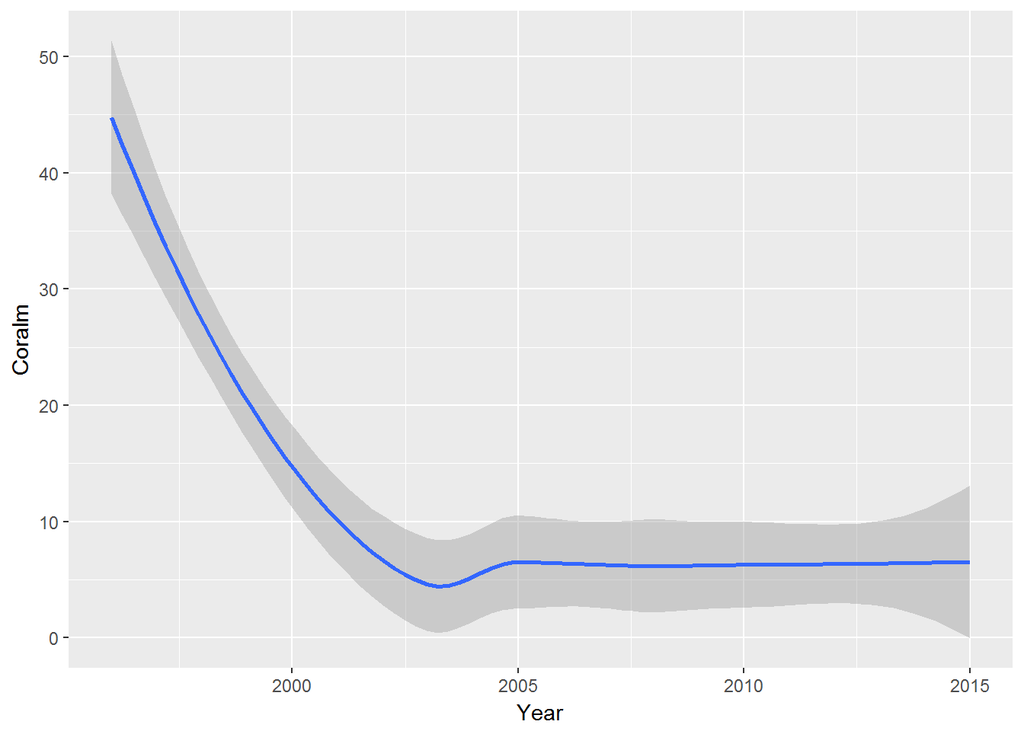

```r
setwd(RESULTS_DIRECTORY)
load(sprintf("Sample_%s.Rdata",5))

library(ggplot2)
library(dplyr)
plotresults = Results %>%
  filter(REEF_ID=="12-003a") %>%
  group_by(REEF_NAME,Year, Season) %>%
  mutate(COTSA = (COTSA/100)*0.15) %>%
  summarise(COTSm = mean(COTSA, na.rm=T),
            COTSsd = sd(COTSA, na.rm = T),
            Coralm = mean(CoralCover, na.rm=T),
            Coralsd = sd(CoralCover, na.rm = T)) %>%
  mutate(Time = paste0(Year, substr(Season, 1,1)))
ggplot(data=plotresults, aes(x=Year, y=Coralm)) + geom_smooth() #+ geom_smooth(aes(y=COTSm))
```

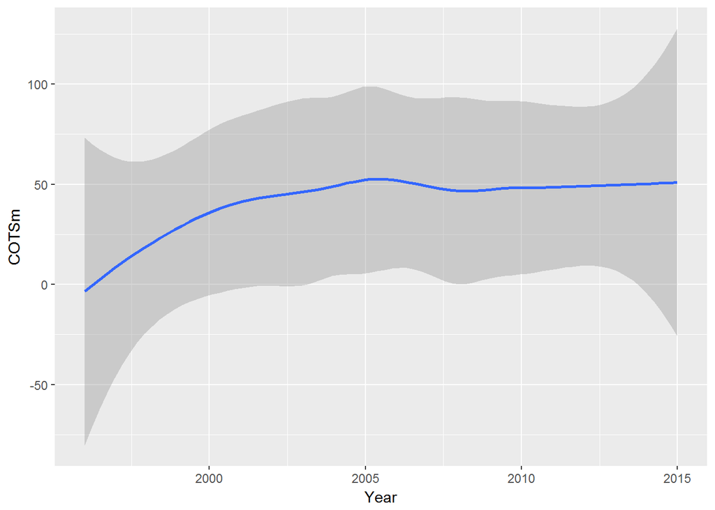

```r
ggplot(data=plotresults, aes(x=Year, y=COTSm)) + geom_smooth()
```